# Data Visualization with ggplot2 in R

Anil

2026-07-30

# Introduction

`ggplot2` is an open-source data visualization package in R based on the **Grammar of Graphics**. Instead of writing long, ad-hoc plotting code, `ggplot2` lets us build a plot layer by layer, where each layer has a well-defined job.

**Why ggplot2?**

- Based on a layered approach — plots are built up piece by piece.
- Produces clear, customizable, publication-quality visualizations.
- Widely used in data analysis, statistics, and data science roles.

## The Seven Layers of the Grammar of Graphics

| # | Layer | Purpose |
| --- | --- | --- |
| 1 | Data | The dataset being visualized |
| 2 | Aesthetics | Maps variables to visual properties (x, y, color, …) |
| 3 | Geometrics | The type of plot (points, lines, bars, …) |
| 4 | Facets | Splits data into subplots (small multiples) |
| 5 | Statistics | Transformations — smoothing, binning, summaries |
| 6 | Coordinates | Controls the plotting plane / axis limits |
| 7 | Themes | Non-data visuals — fonts, gridlines, legend position |

Every `ggplot2` call is built by adding (`+`) these layers together.

# Step 1: Install and Load Required Packages

We’ll use the built-in `mtcars` (Motor Trend Car Road Tests) dataset, which contains fuel consumption and 10 aspects of automobile design and performance for 32 automobiles.

```r
# Run once if not already installed
# install.packages("vctrs")
# install.packages("dplyr")
# install.packages("ggplot2")

library(dplyr)
library(ggplot2)
```

```r
head(mtcars)
```

```
##                    mpg cyl disp  hp drat    wt  qsec vs am gear carb
## Mazda RX4         21.0   6  160 110 3.90 2.620 16.46  0  1    4    4
## Mazda RX4 Wag     21.0   6  160 110 3.90 2.875 17.02  0  1    4    4
## Datsun 710        22.8   4  108  93 3.85 2.320 18.61  1  1    4    1
## Hornet 4 Drive    21.4   6  258 110 3.08 3.215 19.44  1  0    3    1
## Hornet Sportabout 18.7   8  360 175 3.15 3.440 17.02  0  0    3    2
## Valiant           18.1   6  225 105 2.76 3.460 20.22  1  0    3    1
```

```r
summary(mtcars)
```

```
##       mpg             cyl             disp             hp
##  Min.   :10.40   Min.   :4.000   Min.   : 71.1   Min.   : 52.0
##  1st Qu.:15.43   1st Qu.:4.000   1st Qu.:120.8   1st Qu.: 96.5
##  Median :19.20   Median :6.000   Median :196.3   Median :123.0
##  Mean   :20.09   Mean   :6.188   Mean   :230.7   Mean   :146.7
##  3rd Qu.:22.80   3rd Qu.:8.000   3rd Qu.:326.0   3rd Qu.:180.0
##  Max.   :33.90   Max.   :8.000   Max.   :472.0   Max.   :335.0
##       drat             wt             qsec             vs
##  Min.   :2.760   Min.   :1.513   Min.   :14.50   Min.   :0.0000
##  1st Qu.:3.080   1st Qu.:2.581   1st Qu.:16.89   1st Qu.:0.0000
##  Median :3.695   Median :3.325   Median :17.71   Median :0.0000
##  Mean   :3.597   Mean   :3.217   Mean   :17.85   Mean   :0.4375
##  3rd Qu.:3.920   3rd Qu.:3.610   3rd Qu.:18.90   3rd Qu.:1.0000
##  Max.   :4.930   Max.   :5.424   Max.   :22.90   Max.   :1.0000
##        am              gear            carb
##  Min.   :0.0000   Min.   :3.000   Min.   :1.000
##  1st Qu.:0.0000   1st Qu.:3.000   1st Qu.:2.000
##  Median :0.0000   Median :4.000   Median :2.000
##  Mean   :0.4062   Mean   :3.688   Mean   :2.812
##  3rd Qu.:1.0000   3rd Qu.:4.000   3rd Qu.:4.000
##  Max.   :1.0000   Max.   :5.000   Max.   :8.000
```

Identify which columns in `mtcars` are continuous (e.g. `mpg`, `hp`, `wt`) versus categorical/discrete (e.g. `cyl`, `am`, `gear`) — this distinction matters when choosing aesthetics later.

# Step 2: The Data Layer

The data layer defines *what* dataset feeds the plot. Note that with no aesthetics and no geometry, `ggplot2` only draws a blank canvas.

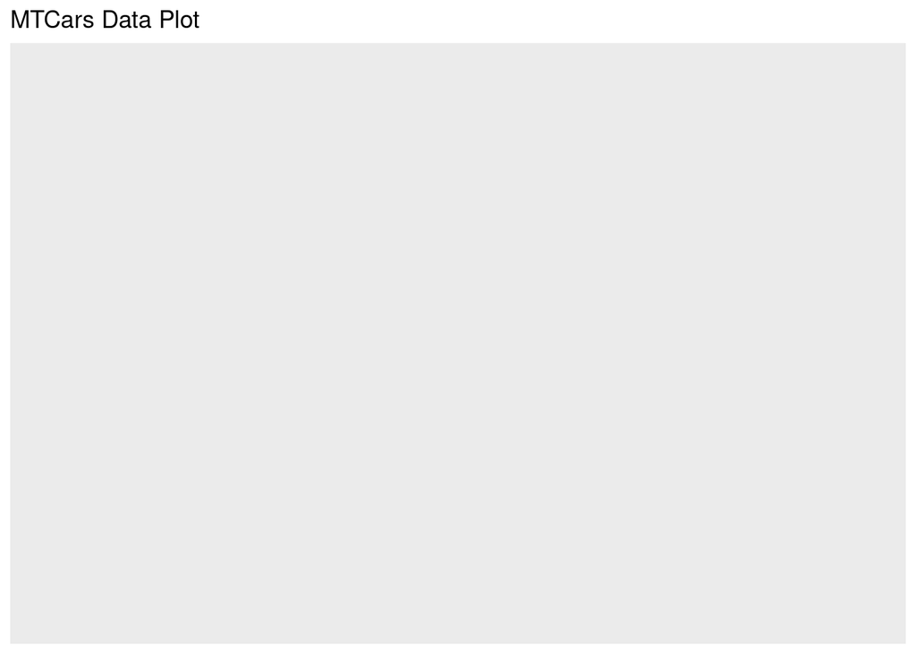

```r
ggplot(data = mtcars) +
  labs(title = "MTCars Data Plot")
```

# Step 3: The Aesthetic Layer (`aes`)

`aes()` maps variables in the data to visual properties. Here we map horsepower (`hp`) to the x-axis, miles per gallon (`mpg`) to the y-axis, and displacement (`disp`) to color.

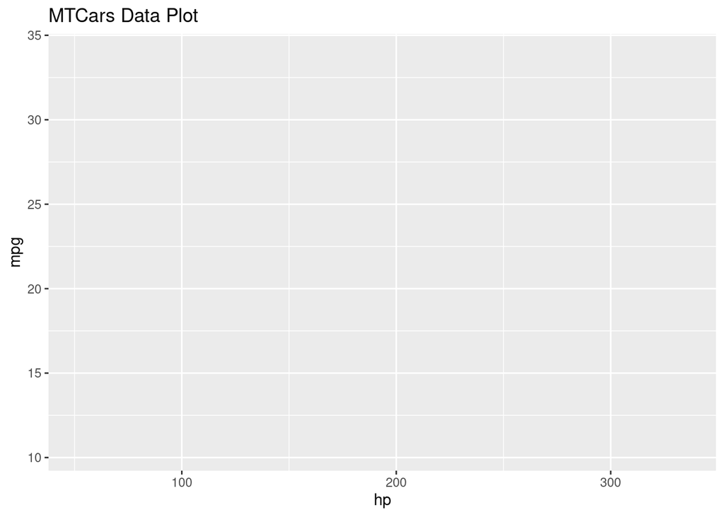

```r
ggplot(data = mtcars, aes(x = hp, y = mpg, col = disp)) +
  labs(title = "MTCars Data Plot")
```

> Notice: the axes are now scaled correctly, but there are still no points on the plot. Aesthetics tell ggplot **where things go** — a geometry layer is required to tell it **what to draw**.

# Step 4: The Geometric Layer

Geometries (`geom_*`) control how data is actually displayed: points, lines, histograms, bars, boxplots, etc.

## 4.1 Basic scatter plot

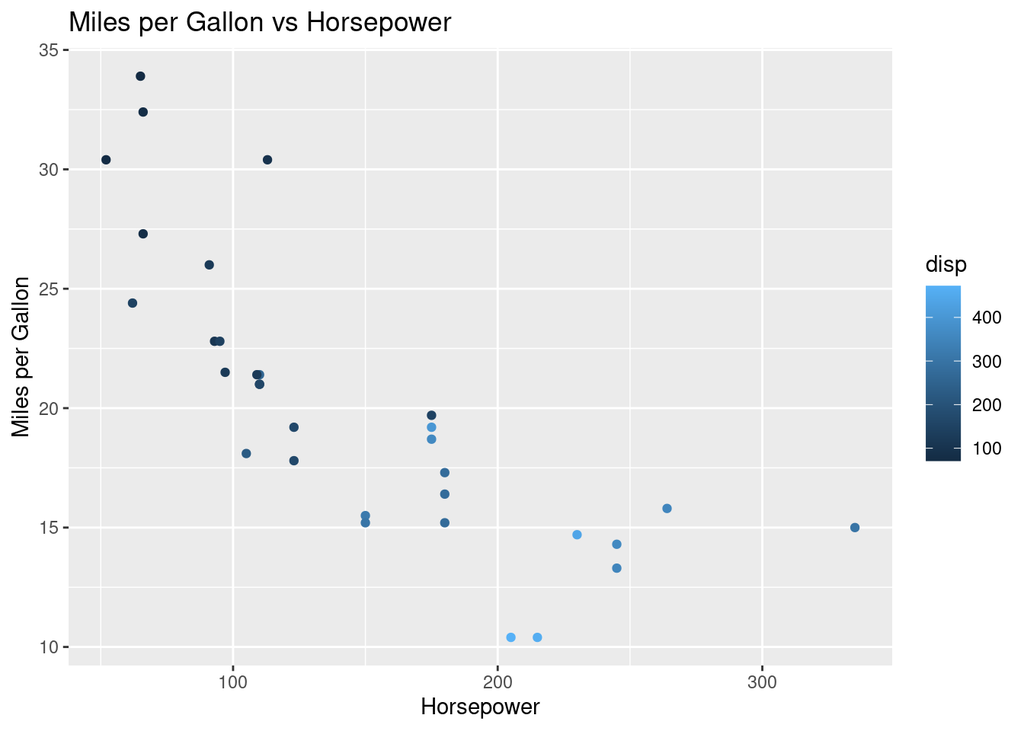

```r
ggplot(data = mtcars, aes(x = hp, y = mpg, col = disp)) +
  geom_point() +
  labs(title = "Miles per Gallon vs Horsepower",
       x = "Horsepower",
       y = "Miles per Gallon")
```

## 4.2 Adding a size aesthetic

Mapping `disp` to point **size** instead of color — larger engines appear as bigger dots.

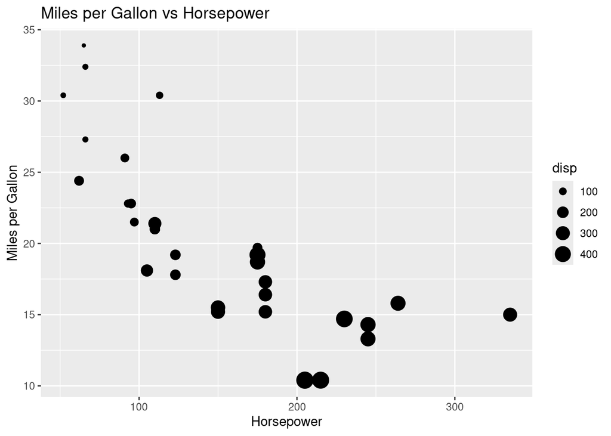

```r
ggplot(data = mtcars, aes(x = hp, y = mpg, size = disp)) +
  geom_point() +
  labs(title = "Miles per Gallon vs Horsepower",
       x = "Horsepower",
       y = "Miles per Gallon")
```

## 4.3 Adding shape and color categories

Using color for cylinder count (`cyl`) and shape for transmission type (`am`) lets us encode two categorical variables in a single plot.

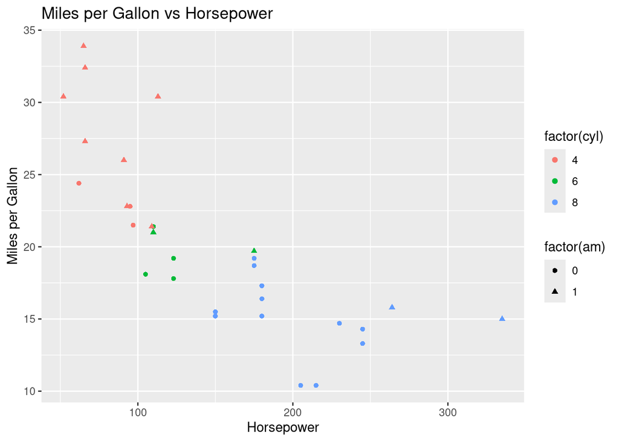

```r
ggplot(data = mtcars, aes(x = hp, y = mpg, col = factor(cyl),
                           shape = factor(am))) +
  geom_point() +
  labs(title = "Miles per Gallon vs Horsepower",
       x = "Horsepower",
       y = "Miles per Gallon")
```

## 4.4 Histogram

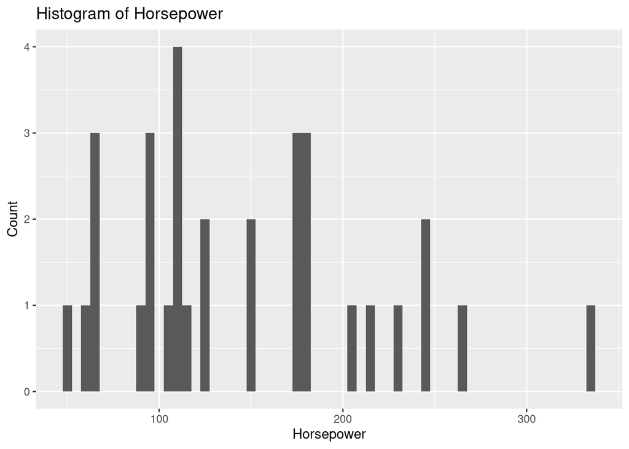

```r
ggplot(data = mtcars, aes(x = hp)) +
  geom_histogram(binwidth = 5) +
  labs(title = "Histogram of Horsepower",
       x = "Horsepower",
       y = "Count")
```

# Step 5: The Facet Layer

Facets split the data into subsets and plot each subset as a small multiple, sharing the same axes — useful for comparing across groups.

## 5.1 Row-wise faceting (`facet_grid(rows ~ .)`)

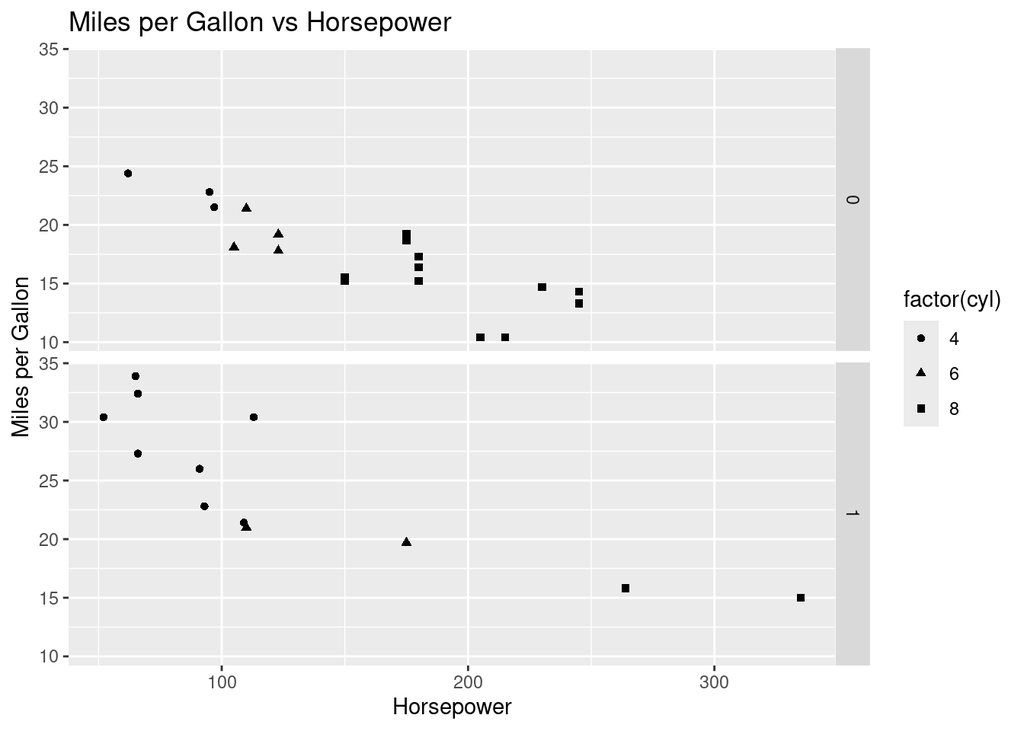

```r
p <- ggplot(data = mtcars, aes(x = hp, y = mpg, shape = factor(cyl))) +
  geom_point()

p + facet_grid(am ~ .) +
  labs(title = "Miles per Gallon vs Horsepower",
       x = "Horsepower",
       y = "Miles per Gallon")
```

## 5.2 Column-wise faceting (`facet_grid(. ~ cols)`)

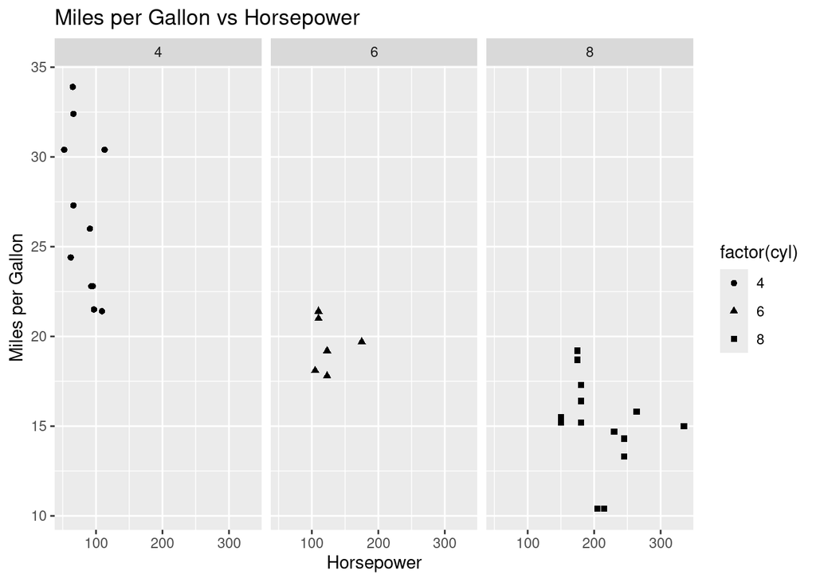

```r
p + facet_grid(. ~ cyl) +
  labs(title = "Miles per Gallon vs Horsepower",
       x = "Horsepower",
       y = "Miles per Gallon")
```

**Tip:** `facet_wrap(~ variable)` is often more convenient than `facet_grid()` when there is only one faceting variable, especially with many categories.

# Step 6: The Statistics Layer

Statistical transformations summarize or model the data — binning, smoothing, descriptive statistics. Here we add a linear regression trend line with `stat_smooth()`.

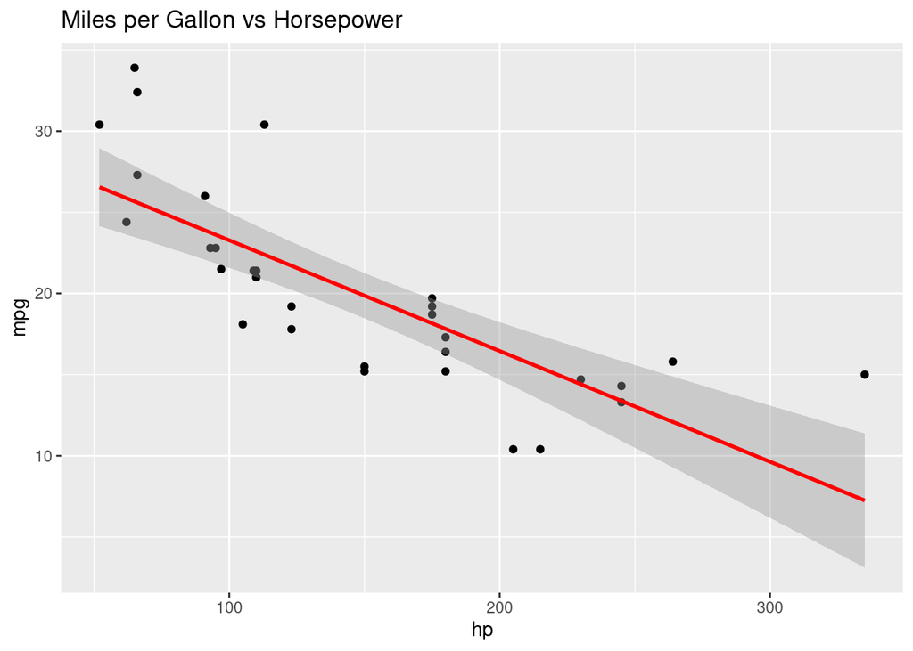

```r
ggplot(data = mtcars, aes(x = hp, y = mpg)) +
  geom_point() +
  stat_smooth(method = lm, col = "red") +
  labs(title = "Miles per Gallon vs Horsepower")
```

The shaded gray band represents the confidence interval around the fitted line.

# Step 7: The Coordinates Layer

The coordinates layer controls the plotting plane itself — axis limits, scaling, and aspect ratio.

## 7.1 Custom axis limits and equal coordinates

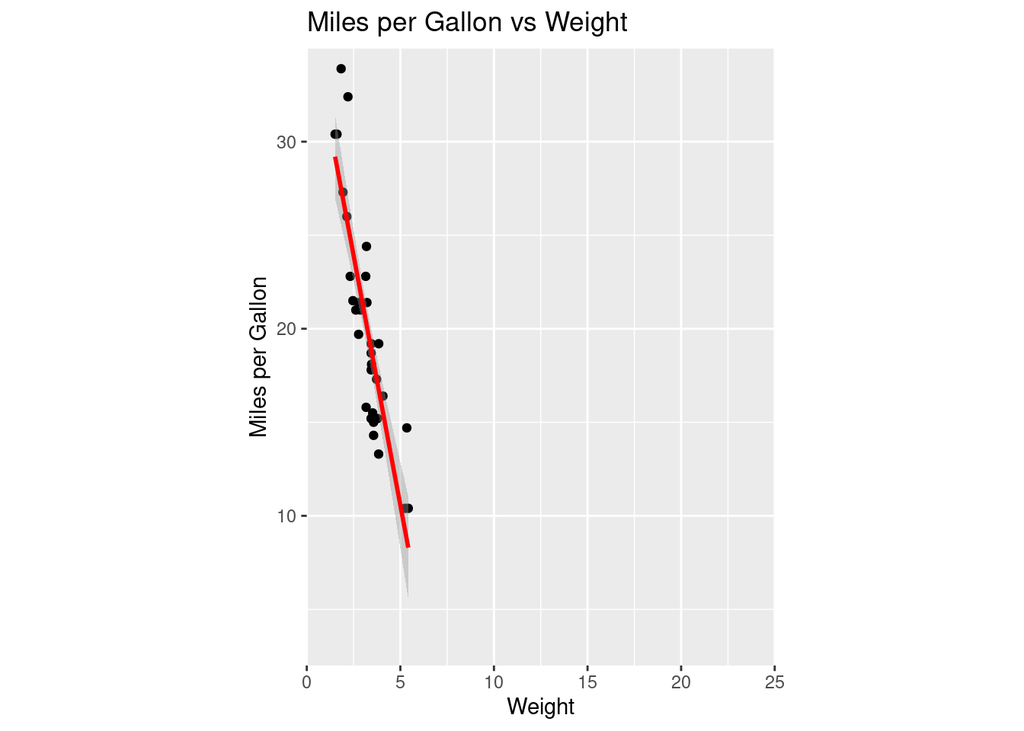

```r
ggplot(data = mtcars, aes(x = wt, y = mpg)) +
  geom_point() +
  stat_smooth(method = lm, col = "red") +
  scale_y_continuous("Miles per Gallon", limits = c(2, 35), expand = c(0, 0)) +
  scale_x_continuous("Weight", limits = c(0, 25), expand = c(0, 0)) +
  coord_equal() +
  labs(title = "Miles per Gallon vs Weight",
       x = "Weight",
       y = "Miles per Gallon")
```

## 7.2 Zooming with `coord_cartesian()`

Unlike `scale_*_continuous(limits = ...)`, which **drops** data outside the range, `coord_cartesian()` zooms in visually without discarding data — important when a smoother is fit over the full dataset.

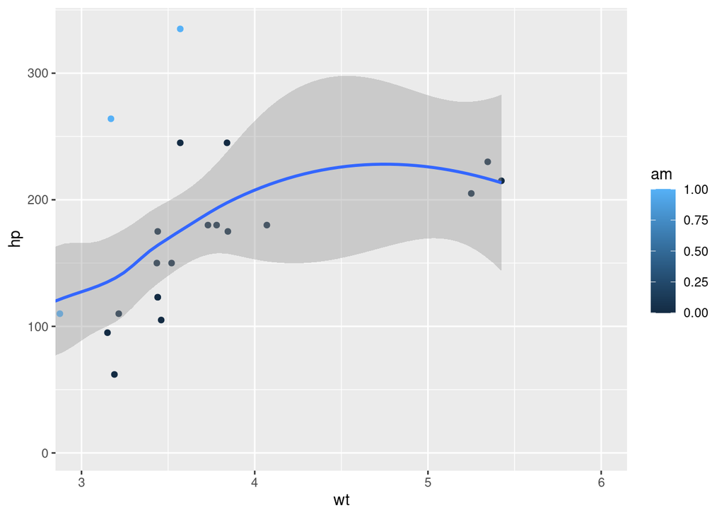

```r
ggplot(data = mtcars, aes(x = wt, y = hp, col = am)) +
  geom_point() +
  geom_smooth() +
  coord_cartesian(xlim = c(3, 6))
```

# Step 8: The Themes Layer

Themes control the non-data ink: grid lines, fonts and text size, and legend position. Common built-in themes include `theme_minimal()`, `theme_classic()`, and `theme_bw()`.

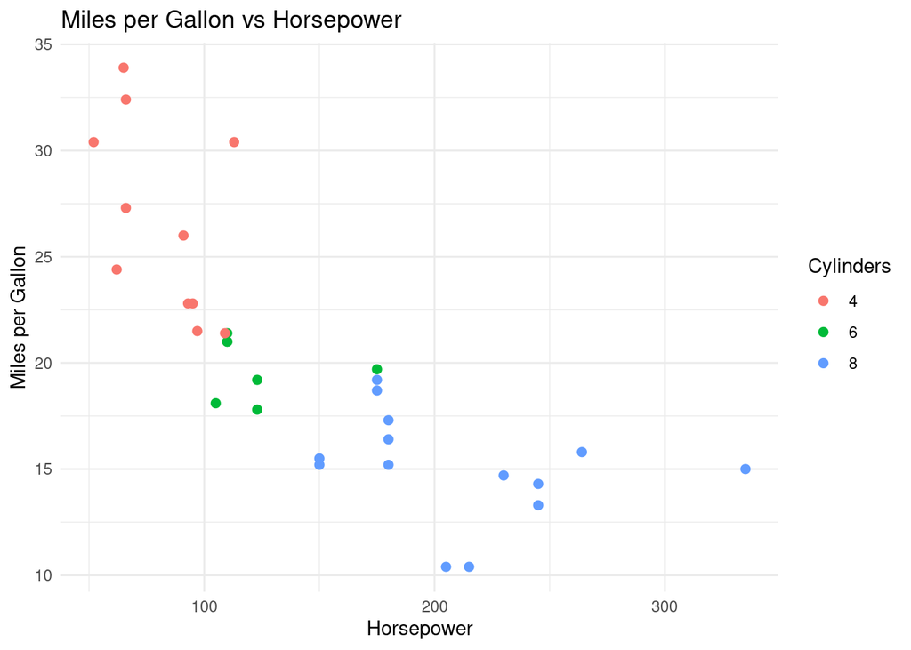

```r
ggplot(data = mtcars, aes(x = hp, y = mpg, col = factor(cyl))) +
  geom_point(size = 2) +
  labs(title = "Miles per Gallon vs Horsepower",
       x = "Horsepower",
       y = "Miles per Gallon",
       col = "Cylinders") +
  theme_minimal()
```

try `theme_minimal()` , `theme_classic()` and `theme_bw()` and discuss which best suits a printed report vs. a dashboard.

# Putting It All Together